# San Jose Police and Fire Department Retirement Plan: preliminary results for discussion

$~$

# 1 **Updates**

## 1.1 Future updates

- Update with 2020 actuarial valuation
- Improve model calibration to better match the results in the actuarial valuation report

$~$

# 2 **Overview**

## 2.1 Policy scenarios

We have modeled the San Jose Police and Fire Department Retirement Plan under its current policy and under three types of alternative policies. The table below summarizes the key features of these polices.

Policy scenarios

|  | Benefit accrual | Max benefit | COLA | Employee contribution | POB |
| --- | --- | --- | --- | --- | --- |
| **Baseline (current policy)** | Tier1: 2.5%~4% Tier2: 2.4%~3.4% | 90% of final average salary | Tier1: 3% fixed Tier2: CPI capped at 2% | Tier1: 27.2% of normal cost Tier2: 50% ADC with limit on annual increase; no less than 50% of normal cost |  |
| **Pre-1999 policy** | Constant 2.5% for new service only | 75% of final average salary | Tier1: 2.5% fixed Tier2: no change |  |  |
| **Cost sharing** |  |  | Suspend COLA before reaching full funding | Tier 2 shared-ADC policy applied to Tier 1 |  |
| **POB of full UAAL** |  |  |  |  | POB of full UAAL, 20 years with 3% interest; equal annual debt service |

1. **Pre-1999 policy:** Benefit provisions for new service are generally consistent with the policies before the major benefit changes around 1999.
   - For all future years of service for all active employees, “benefit factor” is set to a constant 2.5% per year of service (The benefit factor is multiplied by a plan member’s final salary and years of service to determine the initial retirement benefit.)
   - Maximum benefit is reduced to 75% of final average salary (90% in Baseline). If a plan member has already accrued more than 75% of the final average salary by the time of policy change (2019 in the model), the accrued level will be used as the maximum benefit (still capped by 90%).
   - COLA for tier 1 is reduced from 3% to 2.5%.
   - We assume the reduction in future benefit is immediately reflected in the accrued liability and normal cost.
2. **Cost-sharing policy:**
   - The shared-ADC policy of Tier 2 is applied to Tier 1. Under the shared-ADC policy,
     - employee contribution is equal to 50% of the actuarially determined contribution (ADC)
     - the annual increase of employee contribution cannot be greater than 1/3 percent of payroll.
     - employee contribution cannot be less than 50% of the normal cost.
   - COLA is suspended until the plan reaches full funding, then COLA recovers to the baseline level.
3. **POB of full UAAL:**
   - The POB issuance is equal to the entire amount of UAAL in 2019.
   - Terms of POB: 20 years with 3% interest
   - Equal annual debt service

We assume all policies go fully into effect in the first year. The benefit factor reduction affects future service of current workers and all service of new hires. The COLA suspension affects all current retirees, all current workers, and all new hires.

## 2.2 Investment return scenarios

In the tables below we show results for 2019 (the actuarial valuation year and our first year) and for 2028. The model goes out much further in time and it can be useful to pay attention to later time periods as well to gain a better understanding of investment risks and amortization policies. We have examined these policies and variants under three investment scenarios:

1. Deterministic: 6.75% investment return assumption achieved every year. This is the San Jose police and fire plan assumption in 2019, save for any planned earnings assumption reductions.
2. Deterministic asset shock: This is based loosely on stress-test scenarios used by Pew, which in turn are based loosely on Dodd-Frank assumptions. We assume 6.75% return in 2019, 6.75% in 2020, negative 24% in 2021, then 3 years of 12% (2022-2024), then 6.75% annually thereafter.
3. Stochastic: 6.75% expected mean return, 12% standard deviation: This allows us to see how the policies, particularly the contingent COLA policy, interact with investment return volatility. The tables below provide summary results for the deterministic scenarios. We will add tables for the stochastic return scenario in a later iteration.

# 3 **Impact on contributions and funded status**

## 3.1 Summary

### Dollar values

Estimated impacts on contributions and UAAL of selected policy alternatives

$million

|  | 2019 Employer contribution | 2019 UAAL | 2028 Employer contribution | 2028 UAAL | Total present value over 20 years (2019-2038)<sup>1</sup> Employer contribution | Total present value over 20 years (2019-2038)<sup>1</sup> Employee contribution |
| --- | --- | --- | --- | --- | --- | --- |
| Assumption met (constant 6.75% annual return) |  |  |  |  |  |  |
| Baseline: current policy | 189 | 1,205 | 187 | 568 | 2,053 | 457 |
| POB for full UAAL | 137<sup>2</sup> | 1,205<sup>3</sup> | 141<sup>2</sup> | 828<sup>3</sup> | 1,764 | 457 |
| Pre-1999 benefit | 159 | 866 | 155 | 294 | 1,687 | 444 |
| Cost-sharing policy | 174 | 1,205 | 96 | −174 | 1,428 | 567 |
| Asset shock (-24% in 2021 followed by recovery) |  |  |  |  |  |  |
| Baseline: current policy | 189 | 1,205 | 263 | 1,174 | 2,694 | 460 |
| POB for full UAAL | 137<sup>2</sup> | 1,205<sup>3</sup> | 240<sup>2</sup> | 1,624<sup>3</sup> | 2,594 | 460 |
| Pre-1999 benefit | 159 | 866 | 229 | 893 | 2,284 | 448 |
| Cost-sharing policy | 174 | 1,205 | 172 | 433 | 1,897 | 572 |

<sup>*1*</sup> All existing amortization bases in 2019 are expected to be paid off by 2038; present values are calculated with a discount rate of 6.75%. <sup>*2*</sup> Including POB debt service <sup>*3*</sup> Including outstanding POB

### % difference from Baseline

Estimated impacts on contributions and UAAL of selected policy alternatives

Dollar amount ($million) for the baseline policy; % change from baseline amount under each alternative policy

|  | 2019 Employer contribution | 2019 UAAL | 2028 Employer contribution | 2028 UAAL | Total present value over 20 years (2019-2038)<sup>1</sup> Employer contribution | Total present value over 20 years (2019-2038)<sup>1</sup> Employee contribution |
| --- | --- | --- | --- | --- | --- | --- |
| Assumption met (constant 6.75% annual return) |  |  |  |  |  |  |
| Baseline: current policy ($million) | 189 | 1,205 | 187 | 568 | 2,053 | 457 |
| POB for full UAAL | −27.5%<sup>2</sup> | 0.0%<sup>3</sup> | −24.7%<sup>2</sup> | 45.7%<sup>3</sup> | −14.1% | −0.0% |
| Pre-1999 benefit | −15.8% | −28.1% | −17.5% | −48.3% | −17.8% | −2.8% |
| Cost-sharing policy | −8.2% | 0.0% | −48.7% | −130.6% | −30.5% | 24.0% |
| Asset shock (-24% in 2021 followed by recovery) |  |  |  |  |  |  |
| Baseline: current policy ($million) | 189 | 1,205 | 263 | 1,174 | 2,694 | 460 |
| POB for full UAAL | −27.5%<sup>2</sup> | 0.0%<sup>3</sup> | −8.9%<sup>2</sup> | 38.3%<sup>3</sup> | −3.7% | −0.0% |
| Pre-1999 benefit | −15.8% | −28.1% | −12.8% | −23.9% | −15.2% | −2.8% |
| Cost-sharing policy | −8.2% | 0.0% | −34.6% | −63.1% | −29.6% | 24.2% |

<sup>*1*</sup> All existing amortization bases in 2019 are expected to be paid off by 2038; present values are calculated with a discount rate of 6.75%. <sup>*2*</sup> Including POB debt service <sup>*3*</sup> Including outstanding POB

## 3.2 Deterministic results, with 6.75% annual returns

### Liability

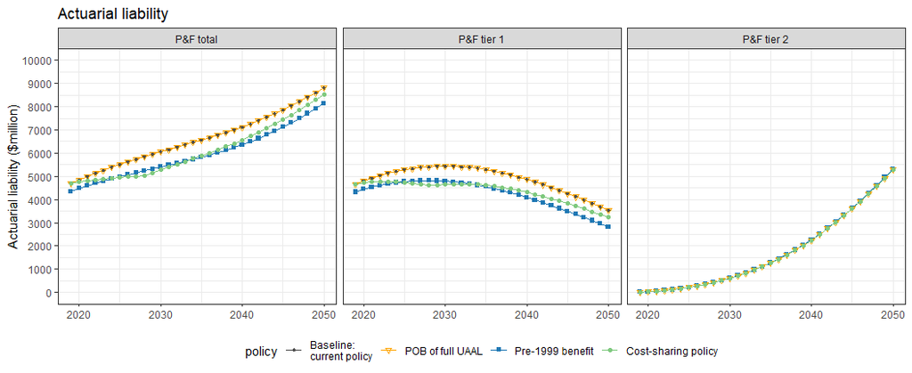

### Funded ratio (MVA)

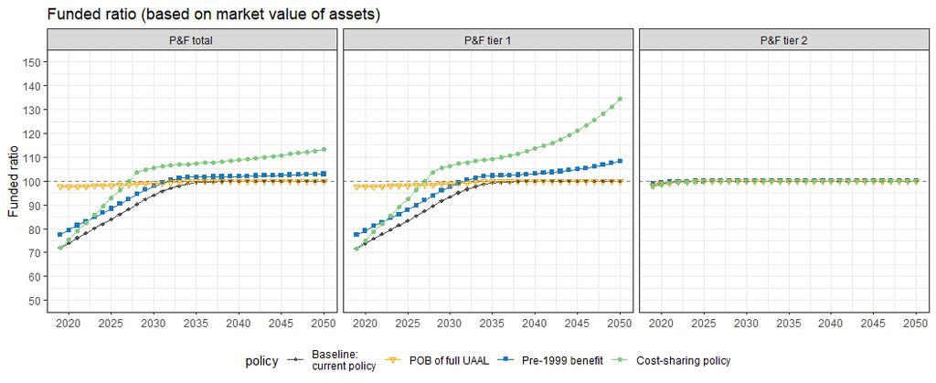

### Employer contribution rate

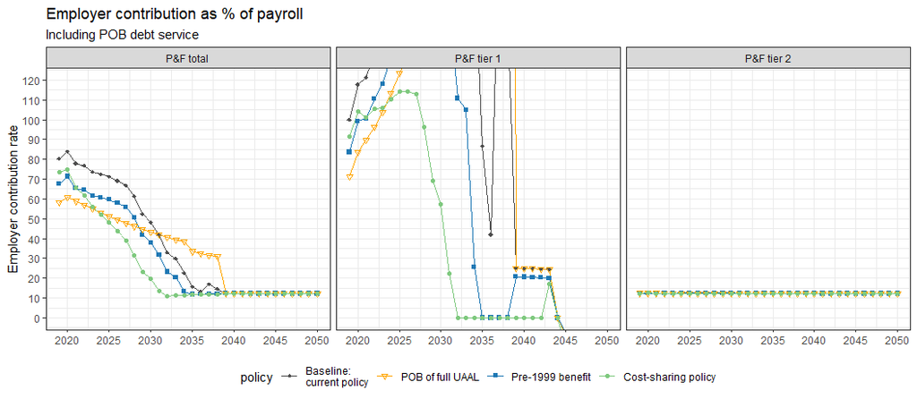

### Employee contribution rate

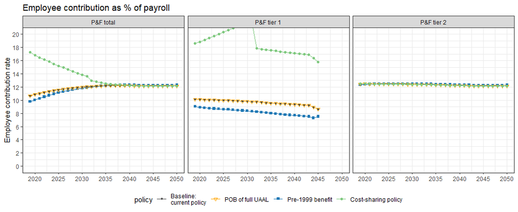

### Total normal cost rate

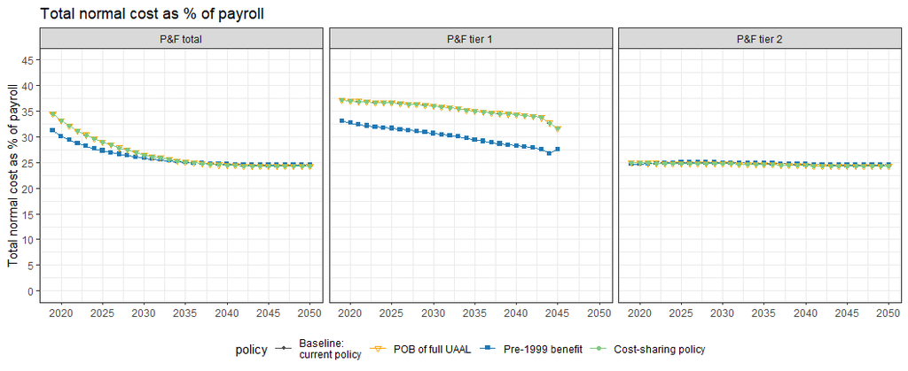

## 3.3 Asset shock scenario (24% decline in portfolio)

### Liability

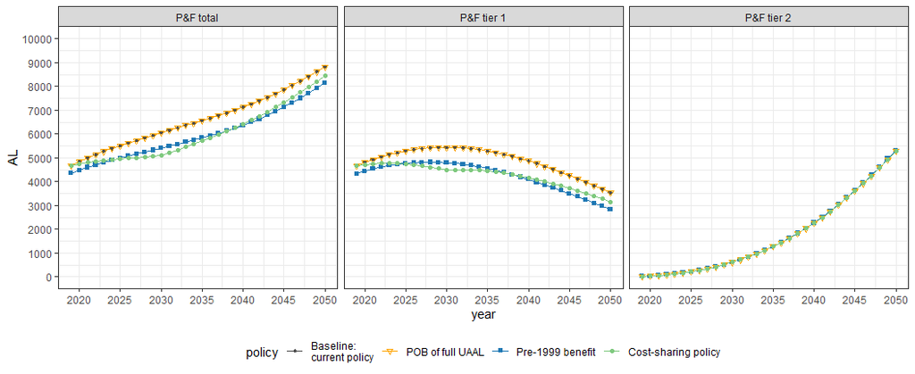

### Funded ratio (MVA)

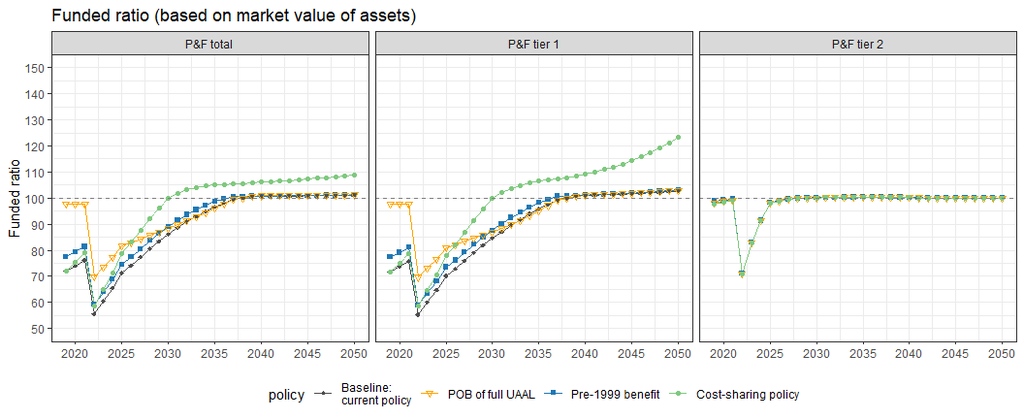

### Employer contribution rate

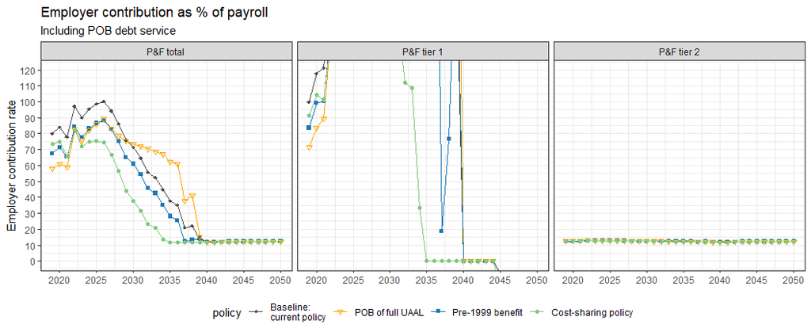

### Employee contribution rate

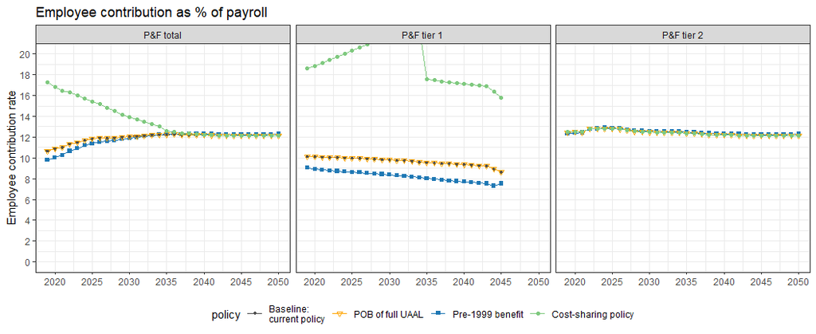

### Total normal cost rate

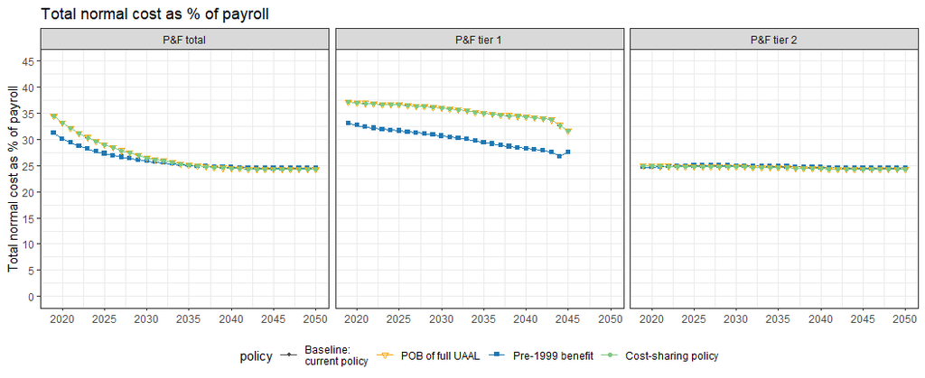

# 4 **Impact on member benefits**

Representative members to examine:

- Tier 1 service retiree at age 55 in 2020
- Late-career tier 1 active member at age 50 in 2020
- Mid-career tier 1 active member at age 35 in 2020
- Early-career tier 2 active member at age 25 in 2020

We assume all members above entered the plan at age 25 and retire at age 55 with 30 years of service.

## 4.1 Benefits

### Benefit at age 80

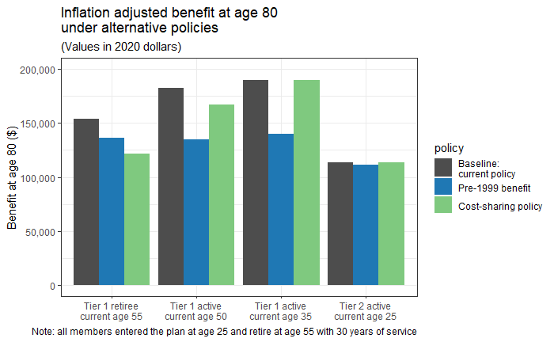

### Benefit at age 55

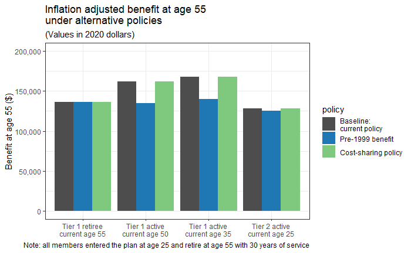

### Total benefit over age 55 to 85

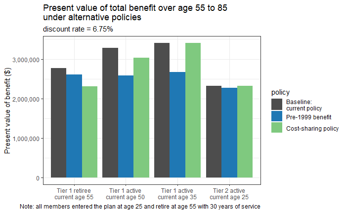

## 4.2 Employee contributions

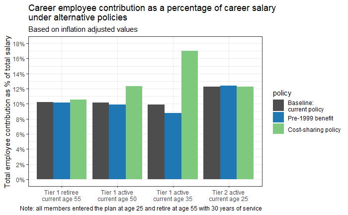